# Regressão linear bayesiana com amostrador de Gibbs

Modelo simples — dado simulado e dado real (`cars`)

Companion literate do `modelo_simples.R`. O algoritmo (as full conditionals, o loop do Gibbs) é o mesmo — aqui só mostra a matemática ao lado do código e do gráfico. Derivação algébrica completa (passo a passo) está em `artigo.pdf`, Seção 3.1; aqui vai só o resultado final de cada full conditional, o suficiente pra ler o código.

**Código**

```r
source("gibbs_helpers.R", encoding = "UTF-8")
```

## Modelo

$$Y_i \overset{iid}{\sim} N\left(\beta_0 + \beta_1 X_i, \ \tau^{-1}\right), \qquad i = 1, \ldots, n$$

com priori independente pra cada parâmetro:

$$\beta_0 \sim N(m_0, \sigma_0^2), \qquad
\beta_1 \sim N(m_1, \sigma_1^2), \qquad
\tau \sim \text{Gama}(a, b)$$

A posteriori conjunta $p(\beta_0, \beta_1, \tau \mid \boldsymbol{y})$ não tem forma fechada — daí o Gibbs. Isolando cada parâmetro na posteriori (conjugação Normal-Normal pra $\beta_0,\beta_1$; Normal-Gama pra $\tau$), as 3 full conditionals saem fechadas:

$$\tau \mid \beta_0, \beta_1, \bs{y} \ \sim\ \text{Gama}\left(\frac{n}{2}+a,\ \ b+\frac{1}{2}\sum_{i=1}^n (y_i-\beta_0-\beta_1 x_i)^2\right)$$

$$\beta_0 \mid \beta_1, \tau, \bs{y} \ \sim\ N(M_0, C_0), \quad
C_0^{-1} = n\tau + \frac{1}{\sigma_0^2}, \quad
M_0 = C_0\left(\tau\sum_i y_i - \tau\beta_1\sum_i x_i + \frac{m_0}{\sigma_0^2}\right)$$

$$\beta_1 \mid \beta_0, \tau, \bs{y} \ \sim\ N(M_1, C_1), \quad
C_1^{-1} = \tau\sum_i x_i^2 + \frac{1}{\sigma_1^2}, \quad
M_1 = C_1\left(\tau\sum_i x_i y_i - \tau\beta_0\sum_i x_i + \frac{m_1}{\sigma_1^2}\right)$$

Gibbs = amostrar essas 3 em sequência, cada uma condicionada no valor mais recente das outras duas. É exatamente o que `gibbs_regressao_linear()` faz — uma função, usada abaixo pros dois conjuntos de dados (simulado e `cars`), sem reescrever o loop.

## Dado simulado

Gera uma amostra com parâmetros verdadeiros conhecidos — serve pra checar se o Gibbs recupera o que foi usado pra simular.

**Código**

```r
set.seed(12)

n   <- 1000
b0  <- 1
b1  <- 0.5
tau <- 2
x   <- rnorm(n)
y   <- b0 + b1 * x + rnorm(n, 0, sqrt(1 / tau))
```

Priori pouco informativa ($\sigma_0^2=\sigma_1^2=1000$, $a=b=0{,}1$):

**Código**

```r
mu0  <- 0; sig0 <- 1000
mu1  <- 0; sig1 <- 1000
a    <- 0.1; b <- 0.1
nsim <- 3 * 10000
```

**Código**

```r
cadeias_sim <- gibbs_regressao_linear(y, x, n, nsim, mu0, sig0, mu1, sig1, a, b)

inds_sim    <- seq(nsim / 2, nsim)
results_sim <- cadeias_sim[inds_sim, ]
real        <- c(b0, b1, tau)
name        <- c(expression(beta[0]), expression(beta[1]), expression(tau))
```

Traceplot (linha tracejada = IC de 95%):

**Código**

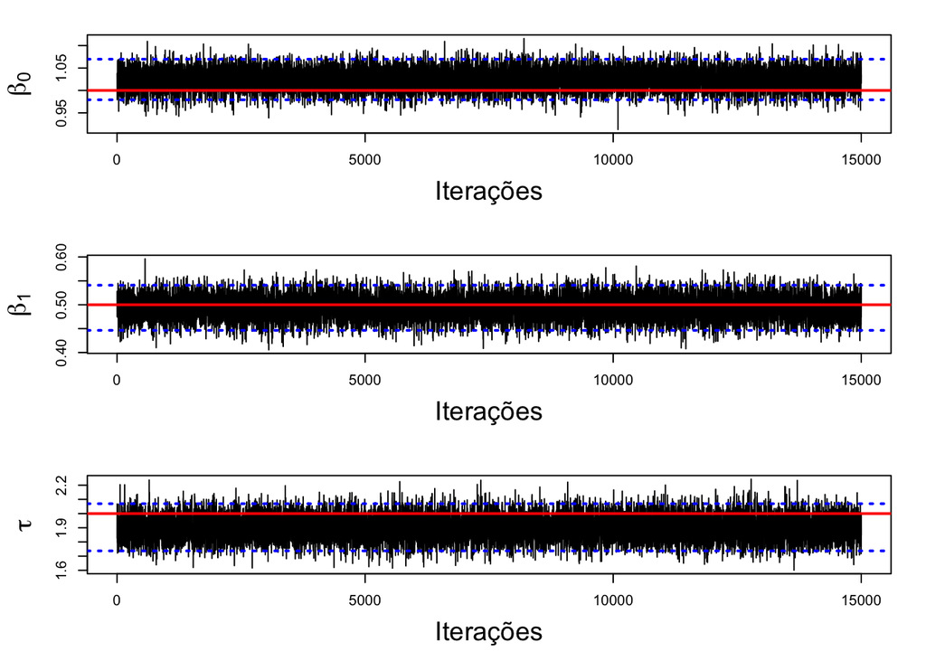

Figura 1: Cadeias de $\beta_0$, $\beta_1$, $\tau$ — dado simulado

```r
cadeia(results_sim, name, real)
```

Histograma + densidade, dividido em 3 blocos da cadeia (checagem informal de mistura — os 3 blocos deviam concordar):

**Código**

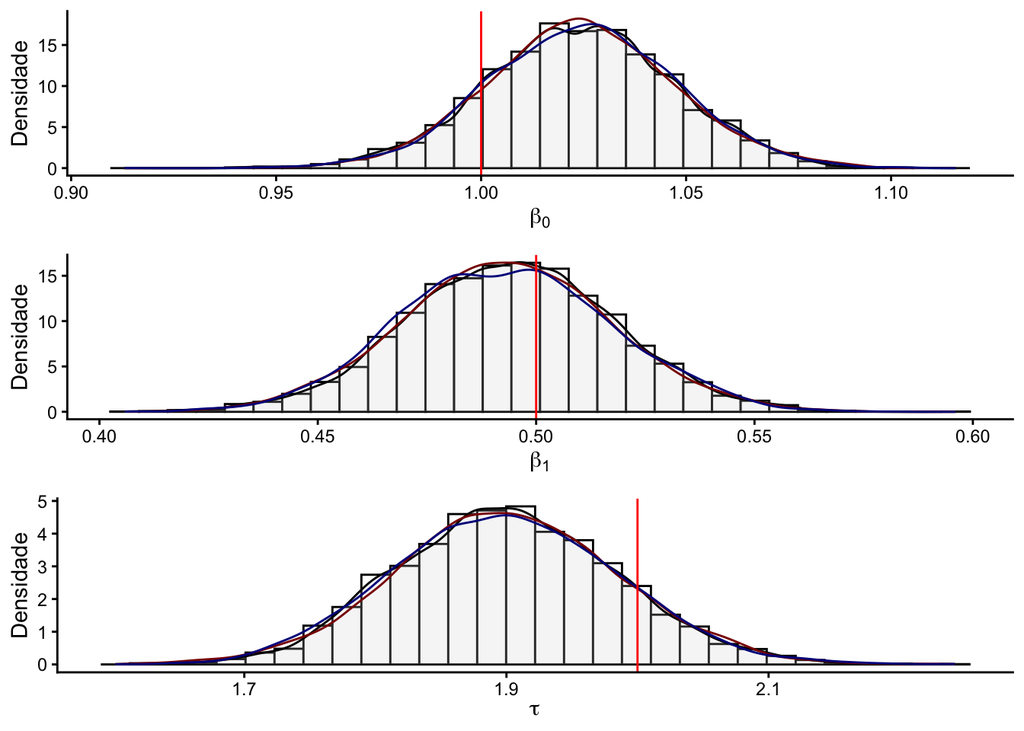

Figura 2: Histograma e densidade — dado simulado

```r
g1 <- hist_den(results_sim[, 1], name = name[1], p = real[1])
g2 <- hist_den(results_sim[, 2], name = name[2], p = real[2])
g3 <- hist_den(results_sim[, 3], name = name[3], p = real[3])
grid.arrange(g1, g2, g3, ncol = 1)
```

Autocorrelação:

**Código**

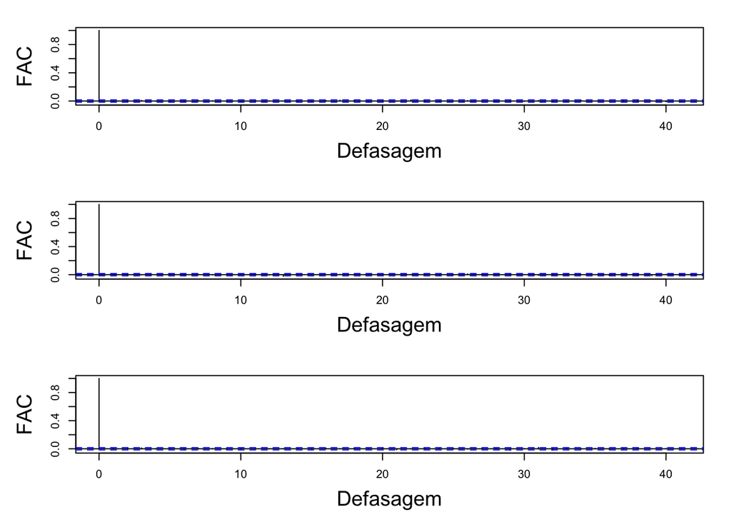

Figura 3: FAC das cadeias — dado simulado

```r
FAC(results_sim)
```

Média posteriori, desvio padrão e IC de 95%, contra o parâmetro real usado na simulação:

**Código**

```r
knitr::kable(coeficientes(results_sim, real = real))
```

Tabela 1

|  | Média | Desv. Pad. | IC inf | IC sup | Real |
| --- | --- | --- | --- | --- | --- |
| cadeia.b0 | 1.0244 | 0.0230 | 0.9792 | 1.0697 | 1.0 |
| cadeia.b1 | 0.4933 | 0.0241 | 0.4464 | 0.5409 | 0.5 |
| cadeia.tau | 1.9001 | 0.0850 | 1.7371 | 2.0695 | 2.0 |

## Dado real (`cars`)

Mesmo modelo, mesma função `gibbs_regressao_linear()` — só troca dado e priori. `cars` é o dataset-base do R: distância de frenagem (`dist`) contra velocidade (`speed`).

**Código**

```r
y <- cars$speed
x <- cars$dist
n <- nrow(cars)
```

Priori um pouco mais informativa pra $\beta_0$ ($\sigma_0^2=100$) e pra $\tau$ ($a=b=2$):

**Código**

```r
mu0  <- 0; sig0 <- 100
mu1  <- 0; sig1 <- 1000
a    <- 2; b <- 2
nsim <- 3 * 10000
```

**Código**

```r
cadeias_cars <- gibbs_regressao_linear(y, x, n, nsim, mu0, sig0, mu1, sig1, a, b)

inds_cars    <- seq(nsim / 2, nsim)
results_cars <- cadeias_cars[inds_cars, ]
classico     <- c(coefficients(lm(cars)), 1 / var(lm(cars)$residuals))
```

**Código**

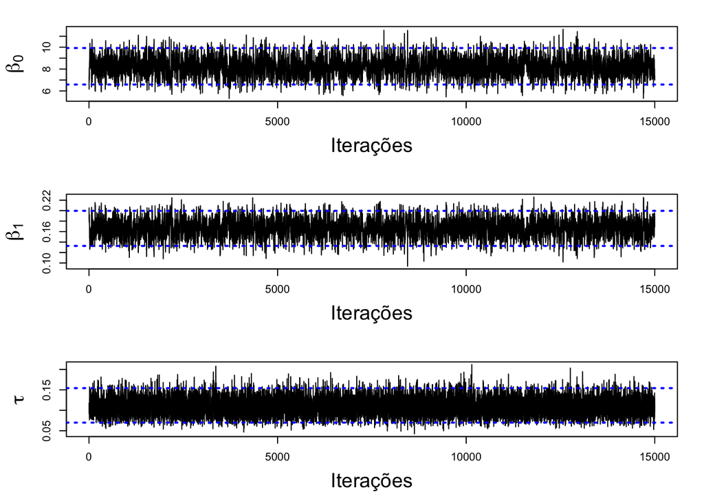

Figura 4: Cadeias de $\beta_0$, $\beta_1$, $\tau$ — cars

```r
cadeia(results_cars, name)
```

**Código**

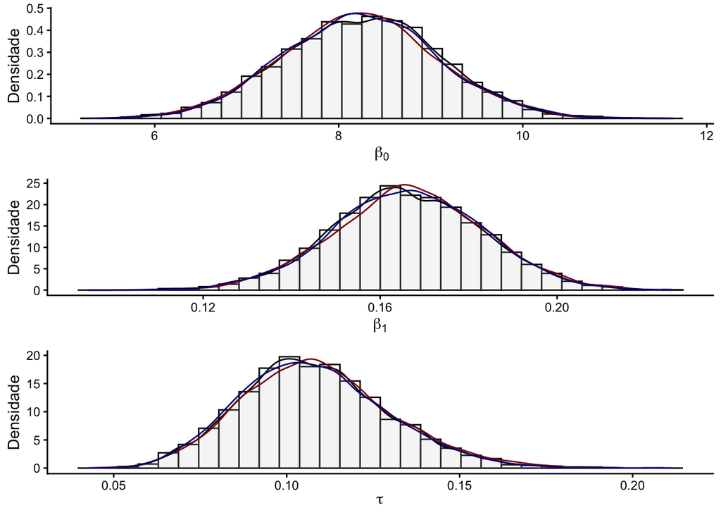

Figura 5: Histograma e densidade — cars

```r
g1 <- hist_den(results_cars[, 1], name = name[1])
g2 <- hist_den(results_cars[, 2], name = name[2])
g3 <- hist_den(results_cars[, 3], name = name[3])
grid.arrange(g1, g2, g3, ncol = 1)
```

**Código**

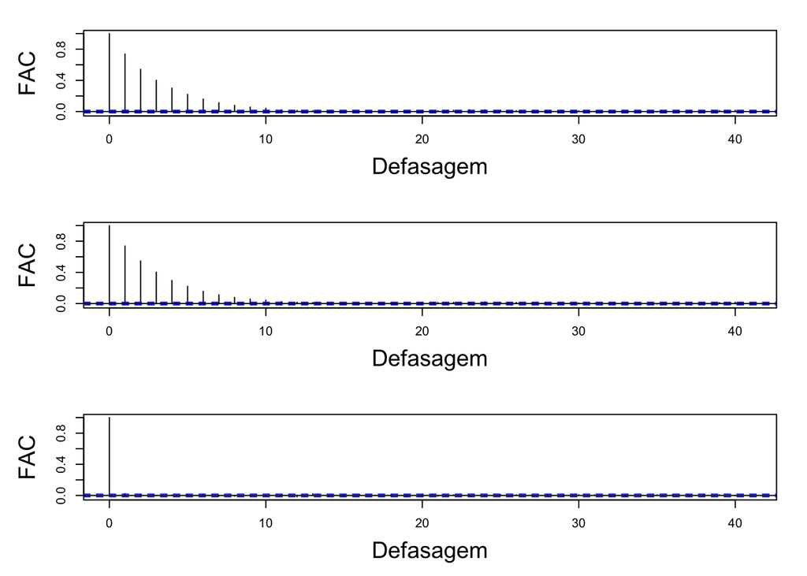

Figura 6: FAC das cadeias — cars

```r
FAC(results_cars)
```

Comparando com o ajuste clássico (`lm()`) no lugar do parâmetro real — aqui não tem parâmetro real, é dado observado, não simulado:

**Código**

```r
knitr::kable(coeficientes(results_cars, real = classico))
```

Tabela 2

|  | Média | Desv. Pad. | IC inf | IC sup | Real |
| --- | --- | --- | --- | --- | --- |
| cadeia.b0 | 8.2374 | 0.8481 | 6.5848 | 9.9239 | 8.2839 |
| cadeia.b1 | 0.1663 | 0.0170 | 0.1326 | 0.1997 | 0.1656 |
| cadeia.tau | 0.1083 | 0.0214 | 0.0699 | 0.1542 | 0.1025 |

Reta clássica (mínimos quadrados) vs reta bayesiana (média posteriori):

**Código**

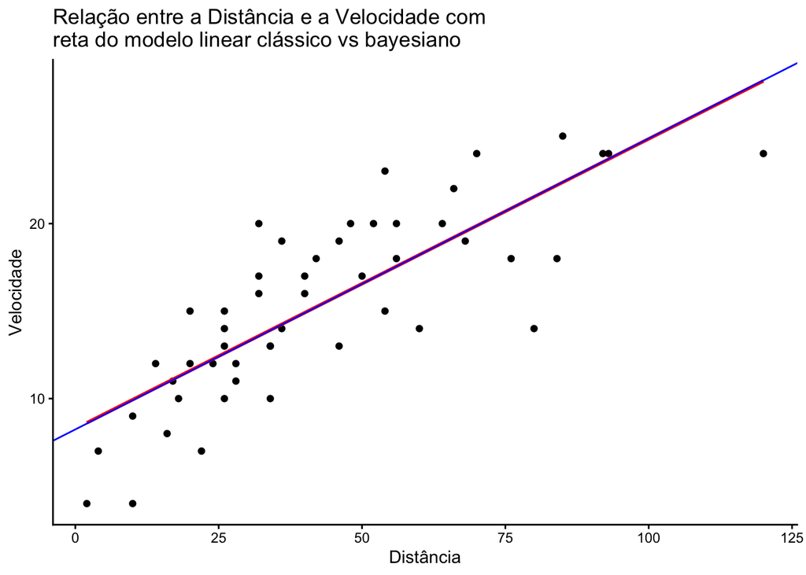

Figura 7: Distância x velocidade — reta clássica vs bayesiana

```r
a_bayes <- mean(results_cars[, 1])
b_bayes <- mean(results_cars[, 2])

cbind(y, x) %>%
  as.data.frame() %>%
  ggplot(aes(y = y, x = x)) +
  geom_point() +
  geom_smooth(method = "lm", se = FALSE, col = "red") +
  theme_classic() +
  geom_abline(slope = b_bayes, intercept = a_bayes, col = "blue") +
  labs(
    title = "Relação entre a Distância e a Velocidade com\nreta do modelo linear clássico vs bayesiano",
    x = "Distância",
    y = "Velocidade"
  )
```

Vermelho = clássico (`lm`), azul = bayesiano (média posteriori). Com priori pouco informativa e $n=50$, as duas retas ficam bem próximas — esperado, é basicamente o ponto da Seção “Motivação” do artigo: priori não informativa tende a concordar com a inferência clássica.